# Test analisa data Insurance

Ronny Raharjo

2/16/2020

# Background

## Setup

Library yang akan digunakan pada analisis regresi

```r
library(dplyr)
library(GGally)
library(lmtest)
library(car)
library(ggplot2)
library(leaps)
library(MLmetrics)
```

# Eksplorasi data

Read data yang akan digunakan

```r
insurance <- read.csv("insurance.csv")
data_test <- read.csv("insurance_test.csv")
```

Berikut merupakan deskripsi dari variabel data insurance:  
- age: umur  
- sex: jenis kelamin  
- bmi: body mass index (ideal di angka 18.5-24.9)  
- children: jumlah anak  
- smoker: merokok atau tidak  
- region: wilayah  
- charges: premi yang harus dibayarkan nasabah

pada kasus ini kita akan memprediksi besarnya premi (charges) yang harus dibayar nasabah berdasarkan variabel- variabel yang ada. Sebelum melakukan eksplorasi lebih dalam, lakukan pengecekan tipe data terlebih dahulu

```r
str(insurance)
```

```
## 'data.frame':    1071 obs. of  7 variables:
##  $ age     : int  19 18 28 33 32 31 46 37 37 60 ...
##  $ sex     : Factor w/ 2 levels "female","male": 1 2 2 2 2 1 1 1 2 1 ...
##  $ bmi     : num  27.9 33.8 33 22.7 28.9 ...
##  $ children: int  0 1 3 0 0 0 1 3 2 0 ...
##  $ smoker  : Factor w/ 2 levels "no","yes": 2 1 1 1 1 1 1 1 1 1 ...
##  $ region  : Factor w/ 4 levels "northeast","northwest",..: 4 3 3 2 2 3 3 2 1 2 ...
##  $ charges : num  16885 1726 4449 21984 3867 ...
```

dari pengecekan tipe data diatas didapati jumlah observasi sebanyak 1071 dan 7 variabel. Untuk mengetahui hubungan antar data yang numerik bisa menggunakan fungsi `ggcorr` dari packages `GGally`

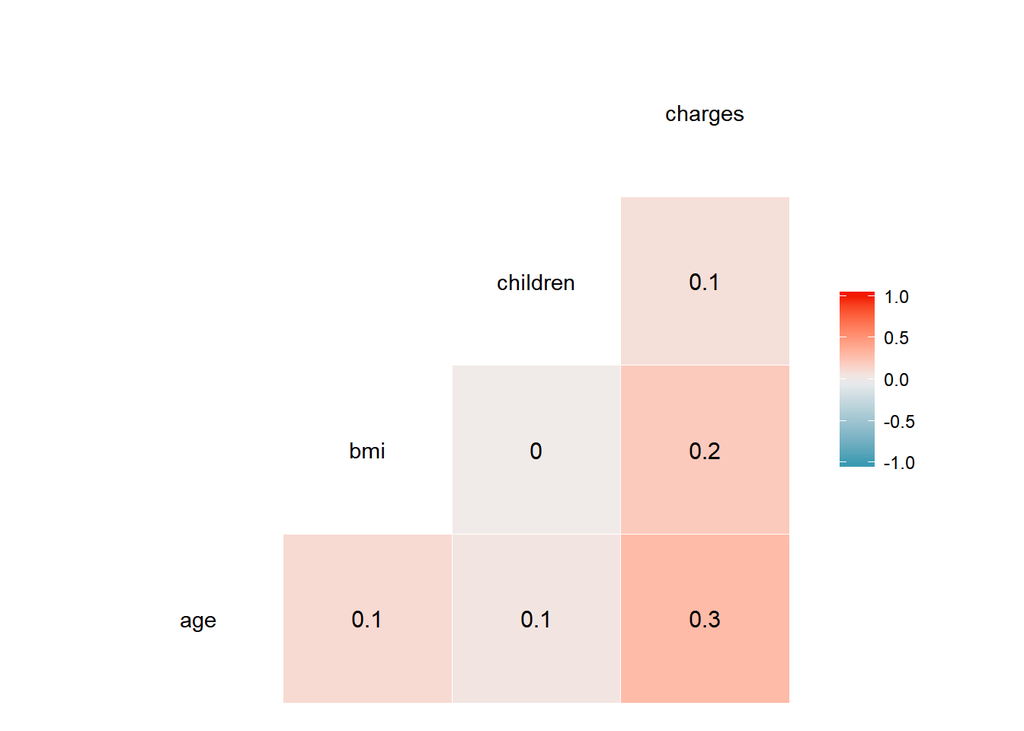

```r
ggcorr(insurance, label = T)
```

dari visualisasi diatas bisa dilihat bahwa korelasi antar variabel relatif kecil. Korelasi tertinggi dimiliki oleh hubungan charges dengan age sebesar 0.3. Selain melakukan pengecekan korelasi antar nilai numerik, kita bisa mengeksplor hubungan antar variabel menggunakan visualisasi.

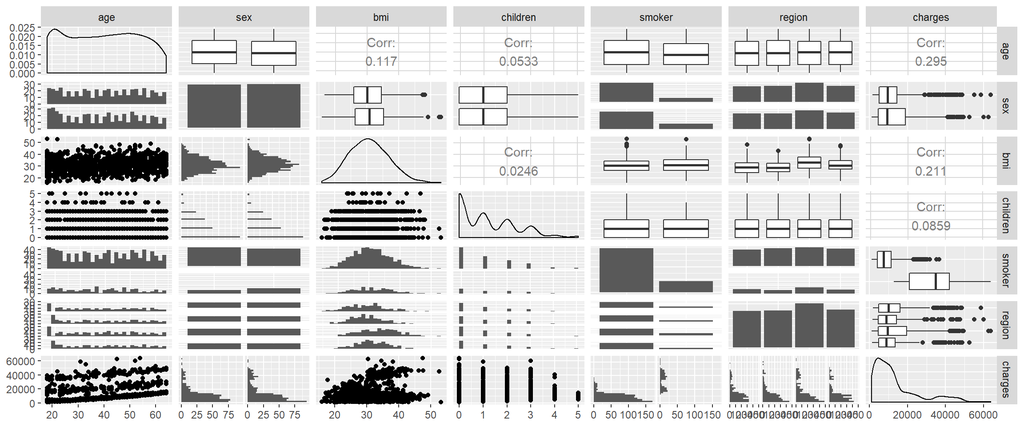

```r
ggpairs(insurance)
```

pengecekan outlier juga dapat dilakukan untuk variabel `charges`

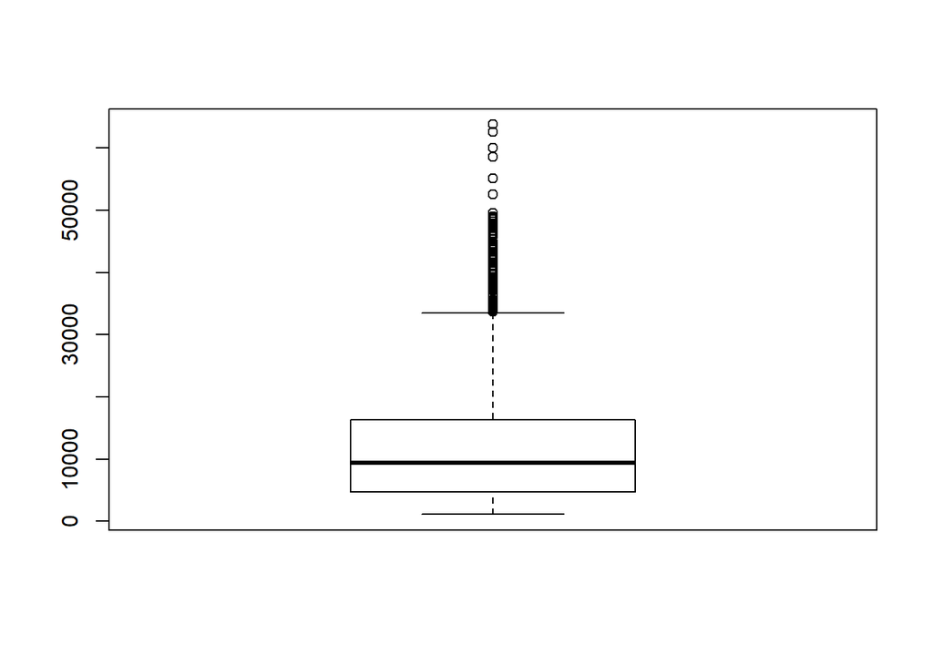

```r
boxplot(insurance$charges)
```

dari visualisasi diatas bisa dilihat bahwa data banyak mengandung outlier. Untuk mengatasi masalah outlier ini ada 2 solusi yaitu :  
1. melakukan remove outlier  
2. melakukan transformasi data (fungsi log)  
untuk analisis kali ini kita tidak akan meremove outlier.

# Modeling

Tahap selanjutnya adalah proses pembuatan model. Pada proses kali ini kita akan membuat model dengan semua varibel terlebih dahulu

```r
model_full <- lm(charges~.,insurance)
summary(model_full)
```

```
##
## Call:
## lm(formula = charges ~ ., data = insurance)
##
## Residuals:
##      Min       1Q   Median       3Q      Max
## -11534.8  -2723.9   -947.1   1414.4  29539.7
##
## Coefficients:
##                  Estimate Std. Error t value Pr(>|t|)
## (Intercept)     -11798.44    1102.36 -10.703  < 2e-16 ***
## age                262.69      13.30  19.746  < 2e-16 ***
## sexmale           -177.16     371.86  -0.476  0.63387
## bmi                329.54      32.15  10.250  < 2e-16 ***
## children           454.48     153.20   2.967  0.00308 **
## smokeryes        24212.81     464.39  52.139  < 2e-16 ***
## regionnorthwest   -461.84     538.24  -0.858  0.39105
## regionsoutheast  -1009.78     532.15  -1.898  0.05803 .
## regionsouthwest  -1052.35     538.31  -1.955  0.05086 .
## ---
## Signif. codes:  0 '***' 0.001 '**' 0.01 '*' 0.05 '.' 0.1 ' ' 1
##
## Residual standard error: 6045 on 1062 degrees of freedom
## Multiple R-squared:  0.7561, Adjusted R-squared:  0.7542
## F-statistic: 411.4 on 8 and 1062 DF,  p-value: < 2.2e-16
```

dari hasil model diatas, didapati Adj R-square sebesar 0.75, namun masih banyak predictor yang tidak signifikan. Langkah selanjutnya adalah melakukan feature selection dengan cara step wise. Pada step wise kali ini direction yang digunakan adalah backward

```r
model_bw <- step(model_full, direction = "backward")
```

```
## Start:  AIC=18659.32
## charges ~ age + sex + bmi + children + smoker + region
##
##            Df  Sum of Sq        RSS   AIC
## - sex       1 8.2942e+06 3.8816e+10 18658
## - region    3 1.8595e+08 3.8993e+10 18658
## <none>                   3.8807e+10 18659
## - children  1 3.2159e+08 3.9129e+10 18666
## - bmi       1 3.8390e+09 4.2646e+10 18758
## - age       1 1.4248e+10 5.3055e+10 18992
## - smoker    1 9.9339e+10 1.3815e+11 20017
##
## Step:  AIC=18657.55
## charges ~ age + bmi + children + smoker + region
##
##            Df  Sum of Sq        RSS   AIC
## - region    3 1.8502e+08 3.9001e+10 18657
## <none>                   3.8816e+10 18658
## - children  1 3.1939e+08 3.9135e+10 18664
## - bmi       1 3.8309e+09 4.2646e+10 18756
## - age       1 1.4304e+10 5.3119e+10 18992
## - smoker    1 9.9972e+10 1.3879e+11 20020
##
## Step:  AIC=18656.64
## charges ~ age + bmi + children + smoker
##
##            Df  Sum of Sq        RSS   AIC
## <none>                   3.9001e+10 18657
## - children  1 3.2106e+08 3.9322e+10 18663
## - bmi       1 3.7843e+09 4.2785e+10 18754
## - age       1 1.4355e+10 5.3356e+10 18990
## - smoker    1 1.0050e+11 1.3950e+11 20020
```

```r
summary(model_bw)
```

```
##
## Call:
## lm(formula = charges ~ age + bmi + children + smoker, data = insurance)
##
## Residuals:
##    Min     1Q Median     3Q    Max
## -12138  -2815   -910   1279  29113
##
## Coefficients:
##              Estimate Std. Error t value Pr(>|t|)
## (Intercept) -12030.07    1050.01 -11.457  < 2e-16 ***
## age            263.34      13.29  19.808  < 2e-16 ***
## bmi            312.37      30.71  10.170  < 2e-16 ***
## children       453.47     153.08   2.962  0.00312 **
## smokeryes    24175.99     461.27  52.412  < 2e-16 ***
## ---
## Signif. codes:  0 '***' 0.001 '**' 0.01 '*' 0.05 '.' 0.1 ' ' 1
##
## Residual standard error: 6049 on 1066 degrees of freedom
## Multiple R-squared:  0.7548, Adjusted R-squared:  0.7539
## F-statistic: 820.6 on 4 and 1066 DF,  p-value: < 2.2e-16
```

dengan menggunakan fungsi step wise kita mendapatkan Adj R-square yang sama yaitu 0.75 namun predictor yang digunakan lebih sedikit. Dari model_bw ini kita bisa mengetahui bahwa age, bmi, children, dan smoke memiliki pengaruh yang positif terhadap charges.

Untuk memastikan bahwa model_bw sudah optimal, kita akan melakukan pengecekan model_bw menggunakan fungsi regsubset

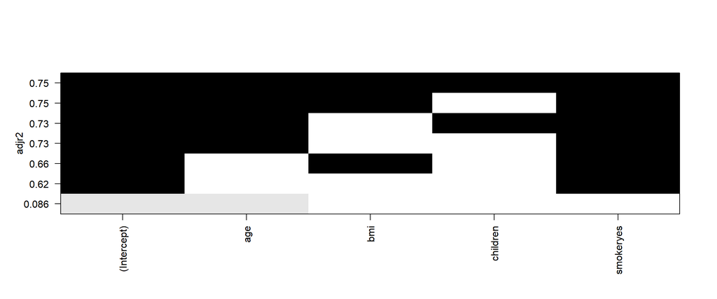

```r
reg_sub <- regsubsets(charges ~ age + bmi + children + smoker, data = insurance, nbest = 2)
plot(reg_sub, scale = "adjr2")
```

dari model diatas didapati bahwa penggunaan semua age,bmi,children, dan smoker adalah kombinasi yang terbaik untuk menghasilkan adj R-square tertinggi.

# Asumsi

## Normality

Pengecekan normality residual bisa di cek menggunakan fungsi shapiro.test, dari hasil pengecekan normality didapat bahwa residual tidak menyebar normal. Salah satu faktor penyebab residual tidak menyebar normal adalah target variabel yang tidak menyebar normal

```r
shapiro.test(model_bw$residuals)
```

```
##
##  Shapiro-Wilk normality test
##
## data:  model_bw$residuals
## W = 0.89909, p-value < 2.2e-16
```

## Homoscedasticity

Pengecekan homoscedasticity menggunakan fungsi bptest menghasilkan p-value lebih kecil dari alpha. Hal ini menunjukkan bahwa ragam dari error tidak tetap. Salah satu cara untuk mengatasi ini adalah melakukan subset data yang digunakan diawal

```r
bptest(model_bw)
```

```
##
##  studentized Breusch-Pagan test
##
## data:  model_bw
## BP = 103.17, df = 4, p-value < 2.2e-16
```

## Multicolinearity

Nilai VIF yang didapat pada model_bw tidak ada yang diatas 10, hal ini menandakan bahwa tidak adanya multicolinearity pada model_bw

```r
vif(model_bw)
```

```
##      age      bmi children   smoker
## 1.018213 1.015049 1.003964 1.002814
```

## Linearity

Linearity perlu dilakukan pengecekan karena pada pemodelan ini kita menggunakan linear regression. Terdapat 2 variabel numerik yang perlu di cek yaitu bmi dan children

```r
cor.test(insurance$bmi, insurance$charges)
```

```
##
##  Pearson's product-moment correlation
##
## data:  insurance$bmi and insurance$charges
## t = 7.0429, df = 1069, p-value = 3.365e-12
## alternative hypothesis: true correlation is not equal to 0
## 95 percent confidence interval:
##  0.1526008 0.2671108
## sample estimates:
##      cor
## 0.210578
```

```r
cor.test(insurance$children, insurance$charges)
```

```
##
##  Pearson's product-moment correlation
##
## data:  insurance$children and insurance$charges
## t = 2.8179, df = 1069, p-value = 0.004924
## alternative hypothesis: true correlation is not equal to 0
## 95 percent confidence interval:
##  0.02609869 0.14502275
## sample estimates:
##        cor
## 0.08586657
```

dari pengecekan kedua linearity diatas diketahui bahwa kedua variabel memiliki hubungan dengan variabel charges

# Prediction

Tahap terakhir adalah melakukan prediksi terhadap data test

```r
pred <- predict(model_bw, data_test)
```

setelah dilakukan prediksi terhadap data test, perlu dilakukan pengeceakan error untuk mengetahui seberapa besar kesalahan yang dihasilkan.

```r
RMSE(pred, data_test$charges)
```

```
## [1] 6156.822
```

```r
MAE(pred, data_test$charges)
```

```
## [1] 4224.226
```

# Kesimpulan

Dalam analisis ini terdapat 2 asumsi yang masih belum terpenuhi yaitu normality of residual dan homoscedasticity. Hal ini bisa atasi dengan melakukan scaling terhadap data yang tidak menyebar normal, dan melakukan filtering terhadap data test. Error yang dihasilkan dalam prediksi ini adalah 6156.822 untuk RMSE dan 4224.226 untk MAE